# Twitter

Joel Soroos

2020-12-06

## Purpose

The goal of this post is to source and analyze Twitter posts and followers for a given Twitter account (“handle”) using R. We will identify tweets with the most likes and retweets, as well as posting trends over time. We will also calculate the geographic distribution of Twitter followers by enriching the raw Twitter data with Google Maps API attributes.

## 1. Setup

First, we need to obtain and authorize a free Twitter Developer account (instructions [here](https://cran.r-project.org/web/packages/rtweet/vignettes/auth.html)).

Second step is to install and load the R [rtweet](https://cran.r-project.org/web/packages/rtweet/rtweet.pdf) package by Michael Kearney.

We will extract Twitter data multiple times so I have created two variables to avoid duplication and inconsistencies. The “twitter_user” variable stores the Twitter handle. The “sample” variable specifies the number of extracted records as some Twitter accounts have large volumes of followers and tweets.

```r
   library (rtweet)

   twitter_user <- "@BlackYellow"
   sample <- 105
```

## 2. Analyze tweets

### Source tweets

Now we will extract our first set of Twitter data, which will be tweets from our specified account. The get_timeline function contains 90 fields on each tweet.

```r
   tweets_raw <- get_timeline (twitter_user, n = sample)
```

### Transform Tweets

Many fields are not needed for this exercise so we can cull the dataset. I have also renamed several fields for brevity and more standard Twitter notation (i.e. likes instead of favorites).

We are focusing on original tweets so have filtered out retweets.

I have extracted year from the creation date to enable summarizing tweet volume by year. Also, I have truncated the Tweet text field from 280 to 60 characters so more cleanly fits in a formatted table.

```r
   library (tidyverse)
   library (lubridate)

   tweets <- tweets_raw %>%
      filter (is_retweet == FALSE) %>%
      rename (
         likes = favorite_count,
         retweets = retweet_count,
         created = created_at
         ) %>%
      mutate (
         text = str_sub(text,1,60),
         created = as.Date(created),
         year = year(created)
         ) %>%
      select (text, year, likes, retweets, created)
```

### Visuialize most liked tweets

We will sort by most liked tweets over time and rank via the dplyr row_to_column formula.

The [gt package](https://gt.rstudio.com/) by Richard Iannone formats tables in a easy-to-read manner. The core gt::gt function adds lines between rows. Many other table formatting enhancements are available but out of scope for this blog.

```r
   library (gt)

   tweets %>%
      arrange (-likes, -retweets) %>%
      head (10) %>%
      rowid_to_column("rank") %>%
      select (-year) %>%
      relocate (rank) %>%
      gt ()
```

| rank | text | likes | retweets | created |
| --- | --- | --- | --- | --- |
| 1 | The last time we faced Frankfurt...💛🏟 https://t.co/hlg7Z18Dl | 11355 | 596 | 2020-12-04 |
| 2 | The link-up 🇳🇴🇺🇸 https://t.co/6gGDP6oy5H | 7424 | 125 | 2020-11-30 |
| 3 | WHAT A STRIKE! 🚀🇺🇸 https://t.co/WRjJvZgSRA | 6202 | 168 | 2020-12-05 |
| 4 | We move ✅ https://t.co/sC1WB3bWct | 4780 | 343 | 2020-12-02 |
| 5 | What a group of lads 💛 🇵🇹🇧🇪🇩🇪🇩🇰🇪🇸🇺🇸🇨🇭🇵🇱🏴 https://t.co | 4197 | 113 | 2020-12-03 |
| 6 | 2020 UEFA Fans' Team of the Year Nominee - Erling Haaland! 🏅 | 3926 | 126 | 2020-12-01 |
| 7 | Special player 🇺🇸💎 https://t.co/MvAMvnCmDi | 3211 | 95 | 2020-12-06 |
| 8 | Penalty for Lazio? | 2945 | 189 | 2020-12-02 |
| 9 | Roman Bürki appreciation tweet 💛🧤 https://t.co/059UcN99Pb | 2892 | 84 | 2020-12-03 |
| 10 | Feeling better, Jude? 😅 https://t.co/HuKrpj2A4X | 2801 | 58 | 2020-12-03 |

### Visualize most retweeted tweets

Next we will re-sort and re-rank by retweets, again using the GT package to cleanly format.

```r
   tweets %>%
      arrange (-retweets, -likes) %>%
      head (10) %>%
      rowid_to_column("rank") %>%
      select (rank, text, retweets, likes, created) %>%
      gt ()
```

| rank | text | retweets | likes | created |
| --- | --- | --- | --- | --- |
| 1 | The last time we faced Frankfurt...💛🏟 https://t.co/hlg7Z18Dl | 596 | 11355 | 2020-12-04 |
| 2 | "I don't need it, I don't need it...I NEED IT!" 🧽 We presen | 467 | 2795 | 2020-12-04 |
| 3 | We move ✅ https://t.co/sC1WB3bWct | 343 | 4780 | 2020-12-02 |
| 4 | RT if this made you smile https://t.co/WHLrbmzlHd | 295 | 1740 | 2020-12-02 |
| 5 | Penalty for Lazio? | 189 | 2945 | 2020-12-02 |
| 6 | WHAT A STRIKE! 🚀🇺🇸 https://t.co/WRjJvZgSRA | 168 | 6202 | 2020-12-05 |
| 7 | 56 \| GIOOOOOOO!!! WE'RE BACK!!! #SGEBVB 1-1 https://t.co/A | 151 | 2147 | 2020-12-05 |
| 8 | 45 \| RAPPPHHAAAA!!! YES!!! WE'RE OFF!!! #BVBLazio 1-0 http | 139 | 1542 | 2020-12-02 |
| 9 | 2020 UEFA Fans' Team of the Year Nominee - Erling Haaland! 🏅 | 126 | 3926 | 2020-12-01 |
| 10 | The link-up 🇳🇴🇺🇸 https://t.co/6gGDP6oy5H | 125 | 7424 | 2020-11-30 |

### Visualize number of tweets trends

Another area of interest is how tweet activity has evolved over time. Using dplyr we can easily summarize by number of tweets by year.

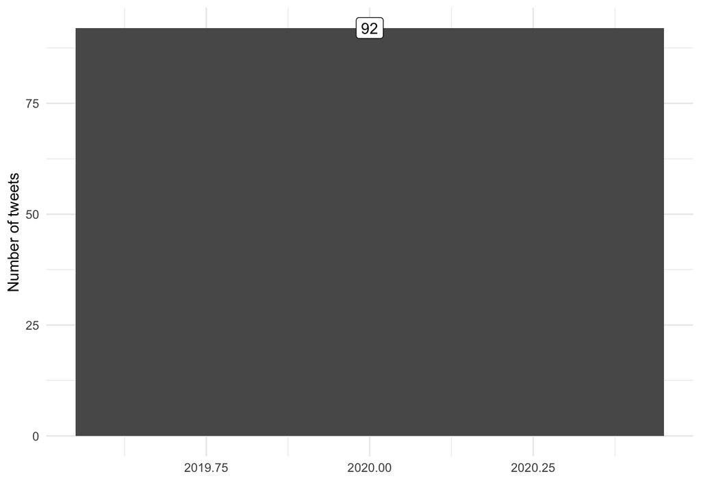

```r
   tweets %>%
      group_by (year) %>%
      count () %>%
      ggplot (aes (x = year, y = n)) +
         geom_col () +
         geom_label (aes(label = n)) +
         theme_minimal() +
         labs (x="", y = "Number of tweets")
```

## 3. Analyze followers

Learning about followers for a Twitter handle is also frequently useful.

Two rtweet package functions are helpful here. First, get_followers returns a vector of Twitter user_ids of followers. The lookup_users function then extracts user attributes such as screen name, physical location (if supplied in profile) and number of followers.

We will also add a row ID ranking each follower by largest number of followers via dplyr’s rowid_to_column function.

```r
   library(skimr)

  followers <- twitter_user %>%
      get_followers() %>%
      pull (user_id) %>%
      lookup_users () %>%
      select (screen_name, name, location, followers_count) %>%
      arrange (-followers_count) %>%
      rowid_to_column("rank")

   skim (followers)
```

Data summary

| Name | followers |
| --- | --- |
| Number of rows | 5000 |
| Number of columns | 5 |
| _______________________ |  |
| Column type frequency: |  |
| character | 3 |
| numeric | 2 |
| ________________________ |  |
| Group variables | None |

**Variable type: character**

| skim_variable | n_missing | complete_rate | min | max | empty | n_unique | whitespace |
| --- | --- | --- | --- | --- | --- | --- | --- |
| screen_name | 0 | 1 | 4 | 15 | 0 | 5000 | 0 |
| name | 0 | 1 | 0 | 50 | 1 | 4884 | 0 |
| location | 0 | 1 | 0 | 34 | 3379 | 1151 | 1 |

**Variable type: numeric**

| skim_variable | n_missing | complete_rate | mean | sd | p0 | p25 | p50 | p75 | p100 | hist |
| --- | --- | --- | --- | --- | --- | --- | --- | --- | --- | --- |
| rank | 0 | 1 | 2500.50 | 1443.52 | 1 | 1250.75 | 2500.5 | 3750.25 | 5000 | ▇▇▇▇▇ |
| followers_count | 0 | 1 | 135.84 | 1586.28 | 0 | 1.00 | 6.0 | 39.00 | 98172 | ▇▁▁▁▁ |

### Top followers

We will first list the 10 largest followers by respective number of followers.

```r
   followers %>%
      head (10) %>%
      select (rank, name, location, followers_count) %>%
      gt () %>%
         fmt_number (columns = vars(followers_count), use_seps = T, decimals = 0)
```

| rank | name | location | followers_count |
| --- | --- | --- | --- |
| 1 | Bybit |  | 98,172 |
| 2 | ana chamuscada 🇫🇷🔥 |  | 28,180 |
| 3 | USMNT Only | United States | 27,770 |
| 4 | ECA | Nyon, Switzerland | 19,271 |
| 5 | Hitekani©️liffy✌🏾 | Tembisa, South Africa | 13,701 |
| 6 | Tim Berry | Oklahoma | 10,198 |
| 7 | Governor Mdogoh | Mombasa | 9,097 |
| 8 | Derek Deis | Spokane, WA | 6,932 |
| 9 | Random Stuff Monger | Maldives | 6,644 |
| 10 | Brian P. Hickey | Philadelphia | 6,160 |

### Obtain follower geographic attributes

Another interesting item to research on followers is geographic distribution.

The provided location in Twitter profile is a good starting point. However, locations are neither standardized by level of detail (city, country) nor spelling. Standardization is necessary to group in table or map.

We will standardize at the highest level of detail, which is country, via the [Google Maps API](https://developers.google.com/maps/documentation) and accessed via the [ggmaps package](https://cran.r-project.org/web/packages/ggmap/ggmap.pdf). If this is the first time you have accessed the Google Maps API, you will need to complete a one-time step of obtaining a free Google maps API key (instructions [here](https://rdrr.io/cran/ggmap/man/register_google.html)).

```r
   library (ggmap)

   register_google(key = Sys.getenv("GOOGLE_MAPS_API"))

   followers_geo <- followers %>%
      head (sample) %>%
      mutate_geocode (location, output = "more") %>%
      mutate (
         country = word (address, -1,-1),
         country = str_to_upper(country),
         country = ifelse(is.na(country), "NOT LISTED", country)
         ) %>%
      select (rank:followers_count, country, lon, lat)

   followers_geo
```

```
## # A tibble: 105 x 8
##     rank screen_name  name     location   followers_count country     lon    lat
##    <int> <chr>        <chr>    <chr>                <int> <chr>     <dbl>  <dbl>
##  1     1 Bybit_Offic… Bybit    ""                   98172 NOT LI…   NA     NA
##  2     2 heronstairs… ana cha… ""                   28180 NOT LI…   NA     NA
##  3     3 usmntonly    USMNT O… "United S…           27770 STATES   -95.7   37.1
##  4     4 ECAEurope    ECA      "Nyon, Sw…           19271 SWITZE…    6.23  46.4
##  5     5 Hitekanicli… Hitekan… "Tembisa,…           13701 AFRICA    28.2  -26.0
##  6     6 theTimothyB  Tim Ber… "Oklahoma"           10198 USA      -97.5   35.5
##  7     7 GovernorMdo… Governo… "Mombasa "            9097 KENYA     39.7   -4.04
##  8     8 DerekKXLY    Derek D… "Spokane,…            6932 USA     -117.    47.7
##  9     9 haesham      Random … "Maldives"            6644 MALDIV…   73.2    3.20
## 10    10 BrianPHickey Brian P… "Philadel…            6160 USA      -75.2   40.0
## # … with 95 more rows
```

### Visualize followers by country

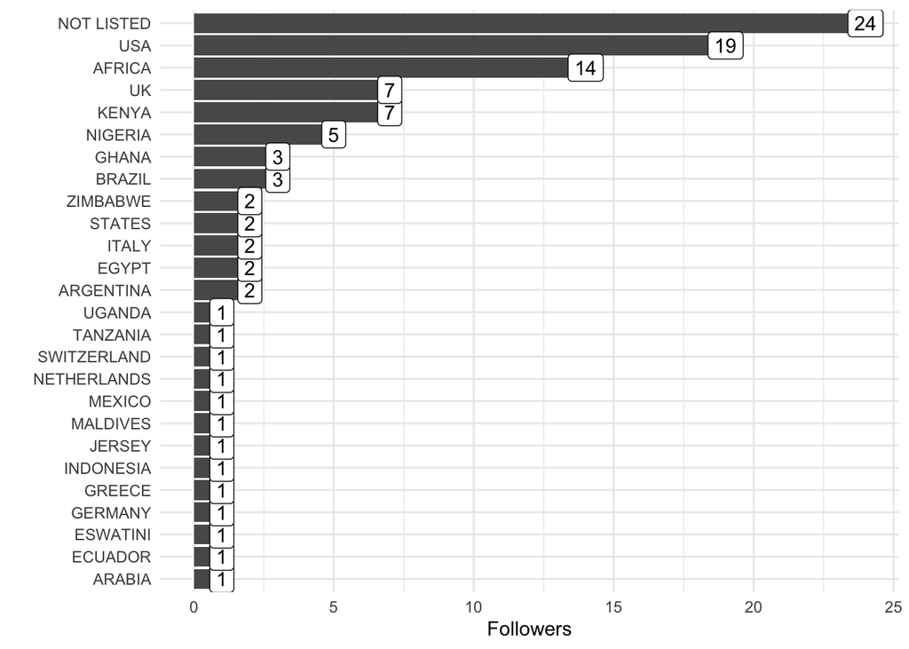

```r
   followers_agg <- followers_geo %>%
      count (country) %>%
      arrange (-n)

   ggplot (followers_agg, aes (x = reorder(country, n), y = n)) +
      geom_col () +
      geom_label (aes(label = n)) +
      coord_flip () +
      theme_minimal() +
      labs (x="", y = "Followers")
```

### Visualize followers on a map

Next we will convert to a map to enable viewing the location of all users along with countries with most users.

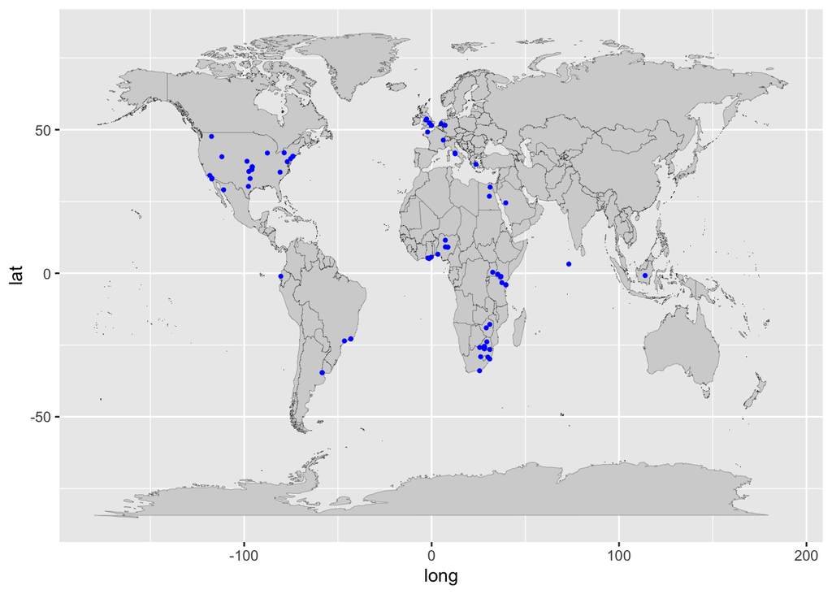

```r
   library (maps)

   world <- map_data ("world")

   ggplot () +
      geom_map (data = world, map = world, aes (long, lat, map_id = region), fill = "lightgray", color = "black", size =0.05) +
      geom_point (data = followers_geo, aes (x = lon, y = lat), color = "blue", size = 0.75) +
      theme_grey ()
```

## 4. Potential future analyses

We are only scratching the surface of available Twitter data, subsequent data enrichment from complementary packages and subsequent analytics. Second generation followers (followers of followers) could easily be sourced and subtotaled to identify possile impact from a tweet. Or Twitter users that the account follows could also be extracted.

## 5. Conclusion

R offers many powerful tools to source, analyze and visualize Twitter information. The Twitter API (accessed via the rtweet package) enables free sourcing of follower and tweet attributes that can be easily imported into R. The raw data can then be enriched by sourcing geographic attributes from Google’s API via the ggpmap package. Tidyverse package such as dplyr, ggplot and GT can then be leveraged to transform and visualize for insight.